# ANOVA test of the data

H NIU

July 21, 2021

Patient characteristics were compared by mortality outcome. For categorical variable, frequenceies and column percentages (%) were reported and p-values were calculated using 2 test or Fisher’s exact test when smallest expected frequencies are lower than 5. Continuous variables were tested for normality using both visual inspections (QQ-plots with histograms) and a formal inspection (Shapiro-Wilk test). Normally distributed continuous variables were reported using means and standard deviations (SD) and p-values were calculated using two-sample t-tests and on-way ANOVAs. Non-normally distributed variables were reported as medians and first/third quartiles, with p-values calculated using Mann–Whitney–Wilcoxon and Kruskal -Wallis tests.

The analyses were done in R programming languages, version 3.6.3. The code has been uploaded on the Github as well https://github.com/niuneo/Mortality-factors-analysis-of-perioperative-cardiac-arrest.

```r
library(tidyselect)
library(readr)
```

```r
library(ggplot2)
library(xlsx)
library(car)
library(dplyr)
library(plyr)
getwd()
```

```
## [1] "C:/Users/neo/Huijie/Code/Predicting CA Mortality/Data"
```

```r
setwd("C:\\Users\\neo\\Huijie\\Code\\Predicting CA Mortality\\Data\\")

data<-read.xlsx("150CA_EN20210701.xlsx",1)

data$Outcome <- ifelse(data$Died ==1, "Died", "Survived")
```

## Part I: Categorical variables: test of independence?

```r
#H0 : the variables are independent, there is no relationship between the two categorical variables.
#H1 : the variables are dependent, there is a relationship between the two categorical variables
#if the p-value is less than the significance level, we can reject the null hypothesis

print('Chi-square test')
```

```
## [1] "Chi-square test"
```

```r
my_seq0 <- c(1,4:20)
# empty legend text
#legend_text <- c(data)

for (i0 in my_seq0) { # variables to compare
  test <- chisq.test(table(data[, i0], data$Outcome))
  test$statistic # test statistic
  test$p.value # p-value
# add next legend text
  print(colnames(data)[i0])
  print('statistic=')
  print(test$statistic) #  test statistic
  print('p-value=')
  print(test$p.value) #  p-value
}
```

```
## [1] "Gender"
## [1] "statistic="
## X-squared
##  5.753873
## [1] "p-value="
## [1] 0.01645235
```

```
## [1] "Comorbidity_diabetes"
## [1] "statistic="
## X-squared
##  1.672186
## [1] "p-value="
## [1] 0.195966
## [1] "Comorbidity_hypertension"
## [1] "statistic="
## X-squared
##   2.11186
## [1] "p-value="
## [1] 0.1461615
## [1] "Comorbidity_CAD"
## [1] "statistic="
## X-squared
##         0
## [1] "p-value="
## [1] 1
## [1] "Comorbidity_pulmonary"
## [1] "statistic="
## X-squared
## 0.4885246
## [1] "p-value="
## [1] 0.4845862
## [1] "Comorbidity_hepatic"
## [1] "statistic="
## X-squared
##  1.084079
## [1] "p-value="
## [1] 0.2977868
## [1] "Comorbidity_renal"
## [1] "statistic="
##   X-squared
## 3.40322e-30
## [1] "p-value="
## [1] 1
## [1] "Comorbidity_neurological"
## [1] "statistic="
##  X-squared
## 0.05023611
```

[output cut: 11 more lines]

```
##  11.68151
## [1] "p-value="
## [1] 0.01988368
## [1] "Emergency"
## [1] "statistic="
## X-squared
##  7.141225
## [1] "p-value="
## [1] 0.007533168
## [1] "Trauma"
## [1] "statistic="
## X-squared
## 0.8655984
## [1] "p-value="
## [1] 0.3521767
```

```
## [1] "Anaesthetic_type"
## [1] "statistic="
##    X-squared
## 6.366345e-31
## [1] "p-value="
## [1] 1
```

```
## [1] "Operative_position"
## [1] "statistic="
## X-squared
##  12.56193
## [1] "p-value="
## [1] 0.01362702
```

```
## [1] "ASA_PS"
## [1] "statistic="
## X-squared
##  26.24712
## [1] "p-value="
## [1] 2.821336e-05
## [1] "Timing_arrest"
## [1] "statistic="
## X-squared
## 0.4172873
## [1] "p-value="
## [1] 0.9366486
## [1] "Defibrillate"
## [1] "statistic="
## X-squared
## 0.4935731
## [1] "p-value="
## [1] 0.4823378
## [1] "Cause_arrest"
## [1] "statistic="
## X-squared
##  4.643279
## [1] "p-value="
## [1] 0.1998607
```

```r
#H0 : the variables are independent, there is no relationship between the two categorical variables.
#H1 : the variables are dependent, there is a relationship between the two categorical variables
#if the p-value is less than the significance level, we can reject the null hypothesis

# The Fisher’s exact test does not require the assumption of a minimum of 5 expected counts.
print('Fishers exact test')
```

```
## [1] "Fishers exact test"
```

```r
my_seq0 <- c(1,4:20)
# empty legend text
#legend_text <- c(data)

for (i0 in my_seq0) { # variables to compare
  test <-fisher.test(table(data[, i0], data$Outcome))
  test$statistic # test statistic
  test$p.value # p-value
# add next legend text
  print(colnames(data)[i0])
  print('statistic=')
  print(test$statistic) #  test statistic
  print('p-value=')
  print(test$p.value) #  p-value
}
```

```
## [1] "Gender"
## [1] "statistic="
## NULL
## [1] "p-value="
## [1] 0.01116523
## [1] "Comorbidity_diabetes"
## [1] "statistic="
## NULL
## [1] "p-value="
## [1] 0.1863895
## [1] "Comorbidity_hypertension"
## [1] "statistic="
## NULL
## [1] "p-value="
## [1] 0.1075058
```

[output cut: 75 more lines]

```r
# 3. Combination of plot and statistical test
#mosaic() function from the {vcd} package.
#This function has the advantage that it combines a mosaic plot (to visualize a contingency table)
#and the result of the Chi-square test of independence

# library(vcd)
#
# mosaic(~ Gender + Outcome,
#        direction = c("v", "h"),
#        data = data,
#        shade = TRUE)
```

## Part II: Continuous variables: a normal distribution?

### Inspection of the normality

```r
#H0: the data follow a normal distribution; H1: the data do not follow a normal distribution
#the p-value>0.05 implys that we do not reject the null hypothesis
#In practice, normality tests are often considered as too conservative in the sense that for large sample size (
#n> 50), a small deviation from the normality may cause the normality condition to be violated

print('in regard to total patients')
```

```
## [1] "in regard to total patients"
```

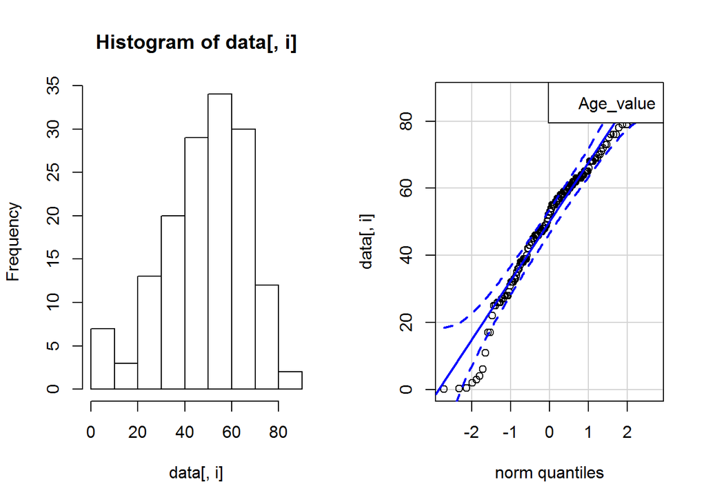

```
## [1] "Age_value"
##
##  Shapiro-Wilk normality test
##
## data:  data[, i]
## W = 0.96325, p-value = 0.000494
```

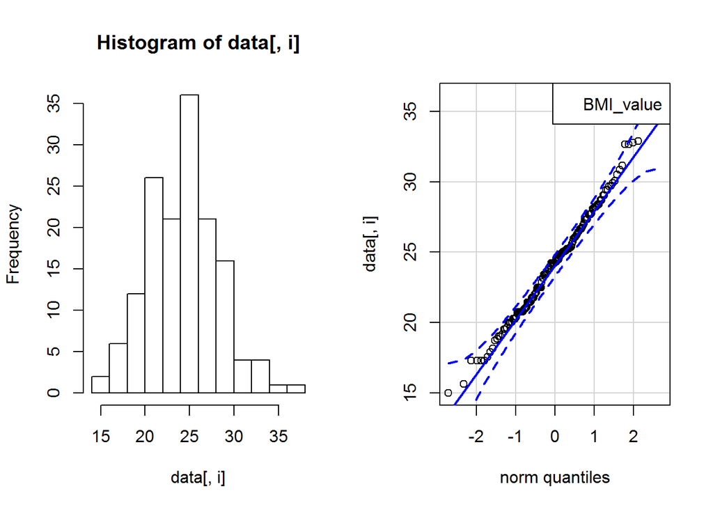

```
## [1] "BMI_value"
##
##  Shapiro-Wilk normality test
##
## data:  data[, i]
## W = 0.99149, p-value = 0.5088
```

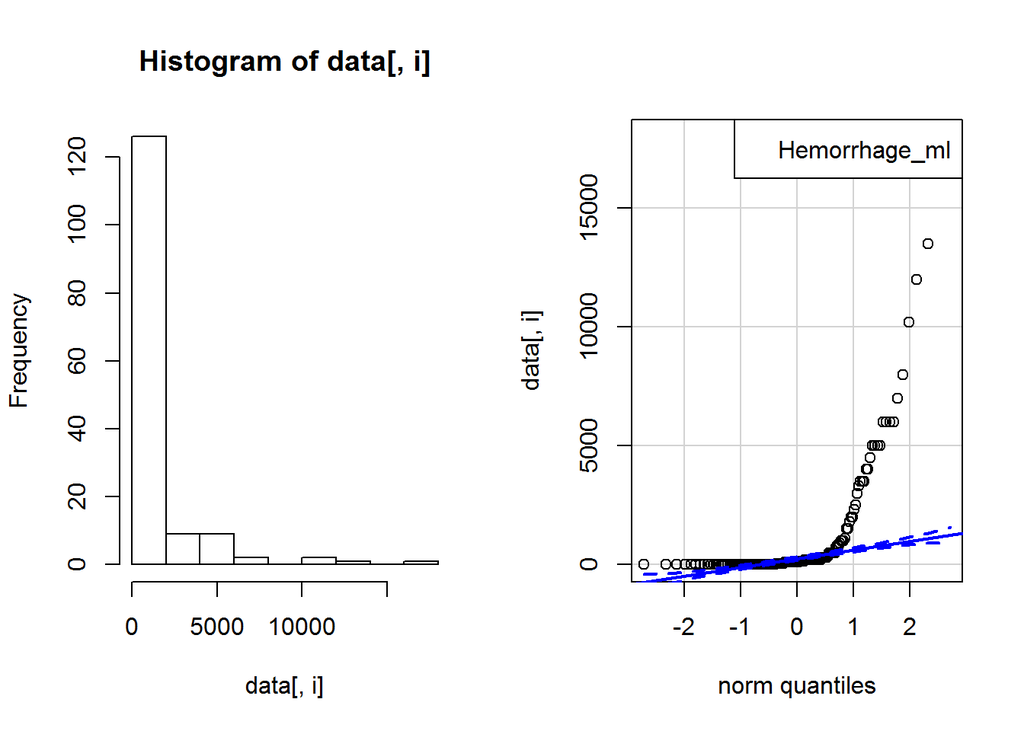

```
## [1] "Hemorrhage_ml"
##
##  Shapiro-Wilk normality test
##
## data:  data[, i]
## W = 0.4961, p-value < 2.2e-16
```

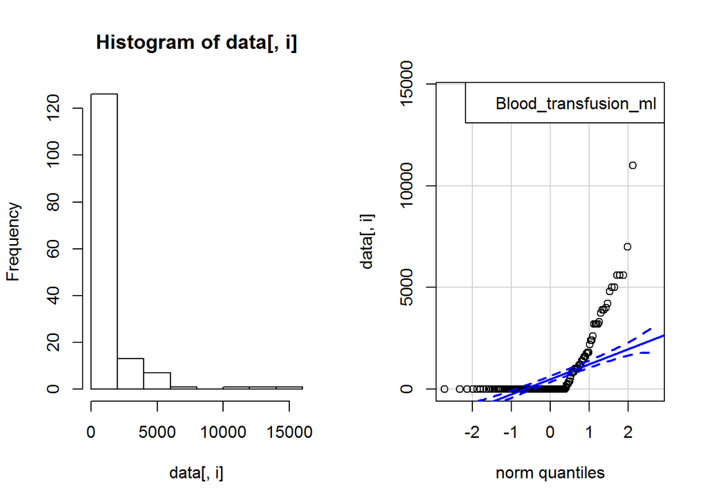

```
## [1] "Blood_transfusion_ml"
##
##  Shapiro-Wilk normality test
##
## data:  data[, i]
## W = 0.50466, p-value < 2.2e-16
```

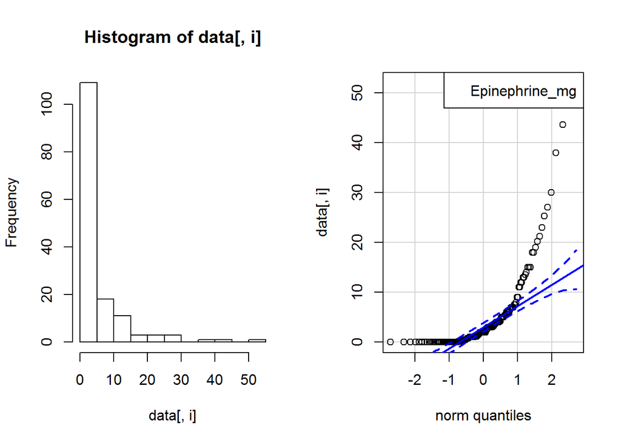

```
## [1] "Epinephrine_mg"
##
##  Shapiro-Wilk normality test
##
## data:  data[, i]
## W = 0.62859, p-value < 2.2e-16
```

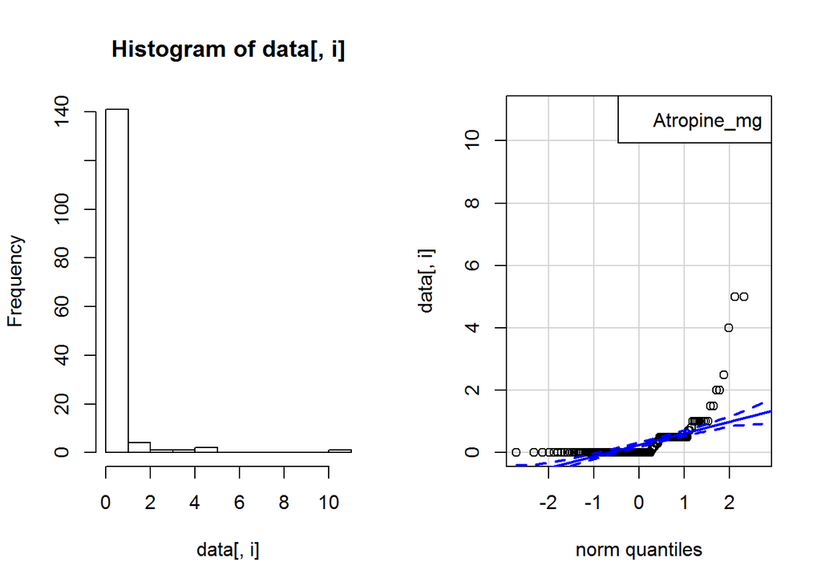

```
## [1] "Atropine_mg"
##
##  Shapiro-Wilk normality test
##
## data:  data[, i]
## W = 0.36384, p-value < 2.2e-16
```

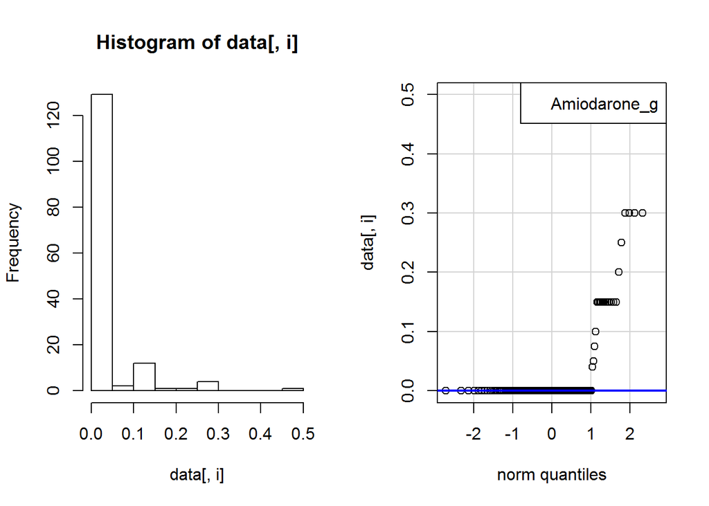

```
## [1] "Amiodarone_g"
##
##  Shapiro-Wilk normality test
##
## data:  data[, i]
## W = 0.42146, p-value < 2.2e-16
```

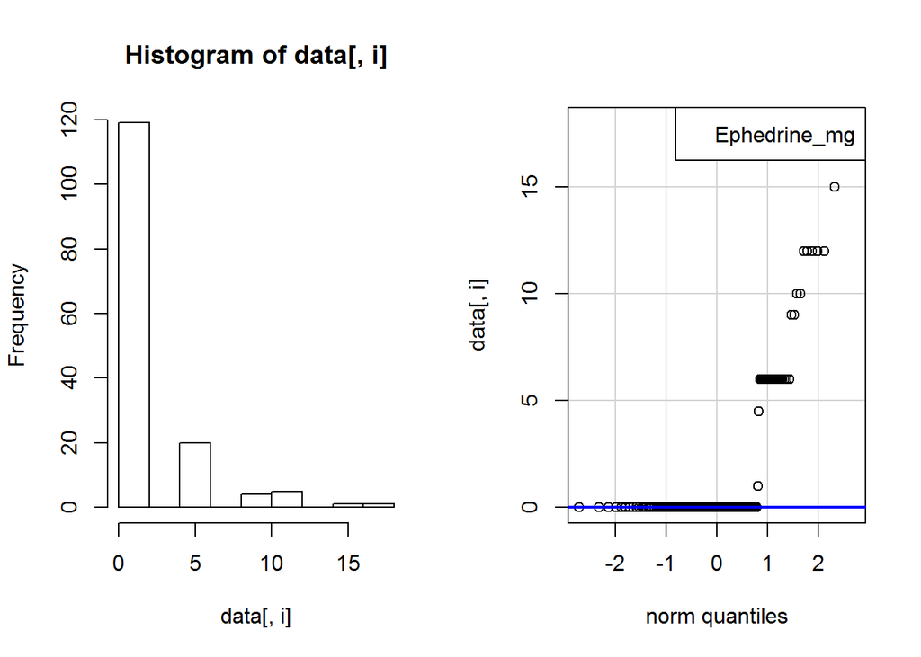

```
## [1] "Ephedrine_mg"
##
##  Shapiro-Wilk normality test
##
## data:  data[, i]
## W = 0.52993, p-value < 2.2e-16
```

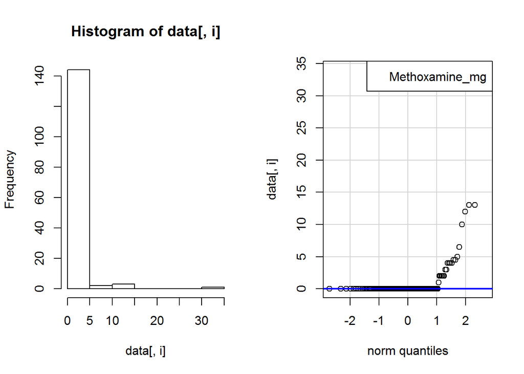

```
## [1] "Methoxamine_mg"
##
##  Shapiro-Wilk normality test
##
## data:  data[, i]
## W = 0.28342, p-value < 2.2e-16
```

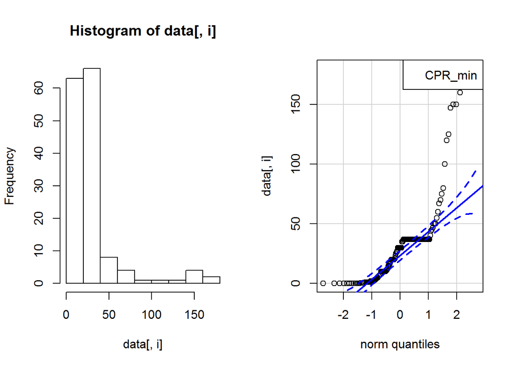

```
## [1] "CPR_min"
##
##  Shapiro-Wilk normality test
##
## data:  data[, i]
## W = 0.71345, p-value = 9.317e-16
```

```r
my_seq <- c(2,3,21:28)
# empty legend text
#legend_text <- c(data)

for (i in my_seq) { # variables to compare
  par(mfrow = c(1, 2)) # combine plots
  hist(data[, i])
  qqPlot(data[, i],id = FALSE # id = FALSE to remove point identification
       )
  # add next legend text
  legend_text <- colnames(data)[i]
  # plot legend once
  legend('topright', legend = legend_text)
  print(colnames(data)[i])
  print(shapiro.test(data[, i])) # print results of Shapiro-Wilk test
}
```

```r
#H0: the data follow a normal distribution; H1: the data do not follow a normal distribution
#the p-value>0.05 implys that we do not reject the null hypothesis
#In practice, normality tests are often considered as too conservative in the sense that for large sample size (
#n> 50), a small deviation from the normality may cause the normality condition to be violated

print('in regard to outcome status=Survived')
```

```
## [1] "in regard to outcome status=Survived"
```

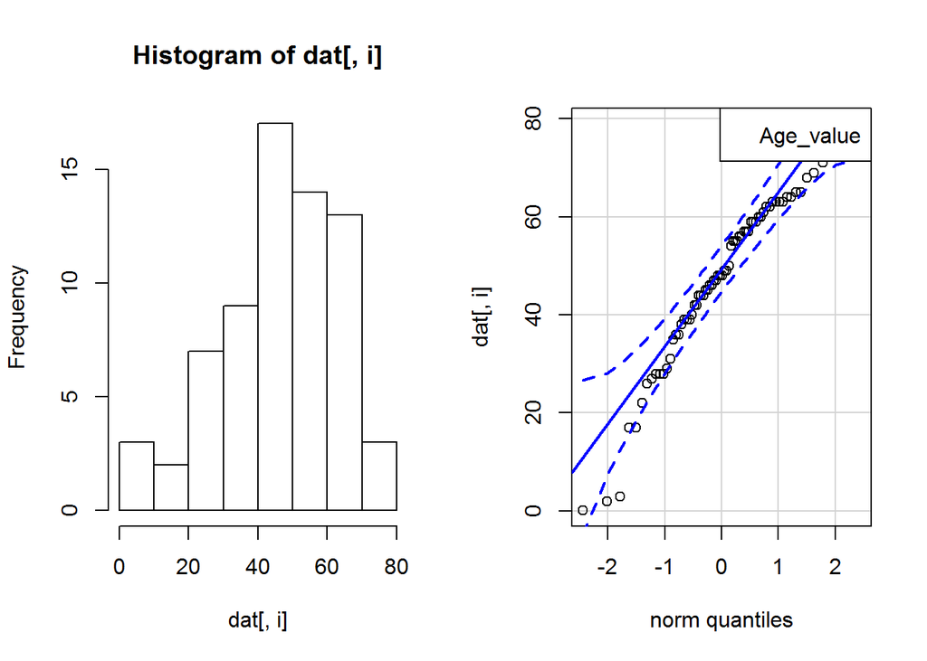

```
## [1] "Age_value"
##
##  Shapiro-Wilk normality test
##
## data:  dat[, i]
## W = 0.9522, p-value = 0.01095
```

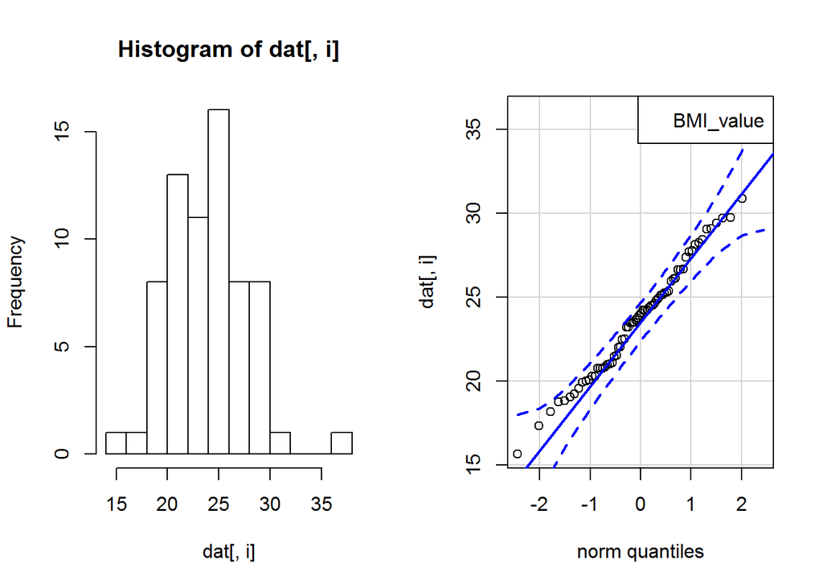

```
## [1] "BMI_value"
##
##  Shapiro-Wilk normality test
##
## data:  dat[, i]
## W = 0.98134, p-value = 0.4014
```

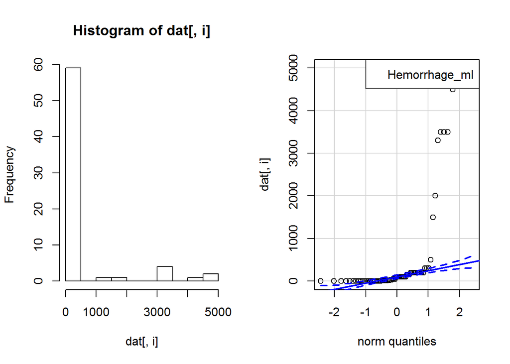

```
## [1] "Hemorrhage_ml"
##
##  Shapiro-Wilk normality test
##
## data:  dat[, i]
## W = 0.47292, p-value = 3.118e-14
```

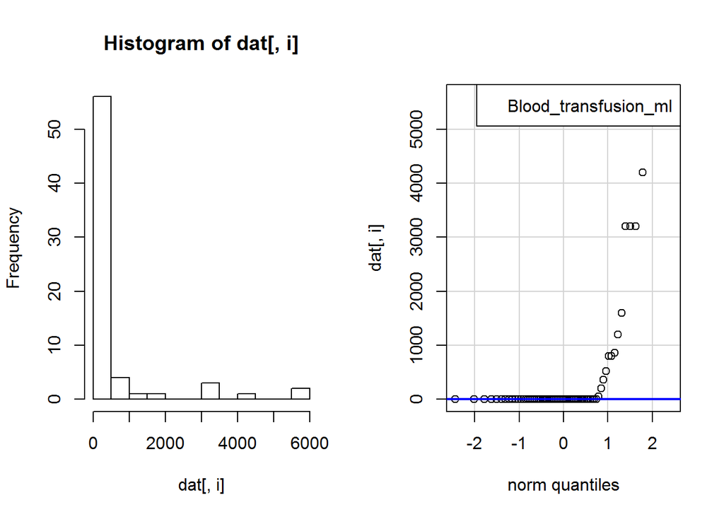

```
## [1] "Blood_transfusion_ml"
##
##  Shapiro-Wilk normality test
##
## data:  dat[, i]
## W = 0.43084, p-value = 8.614e-15
```

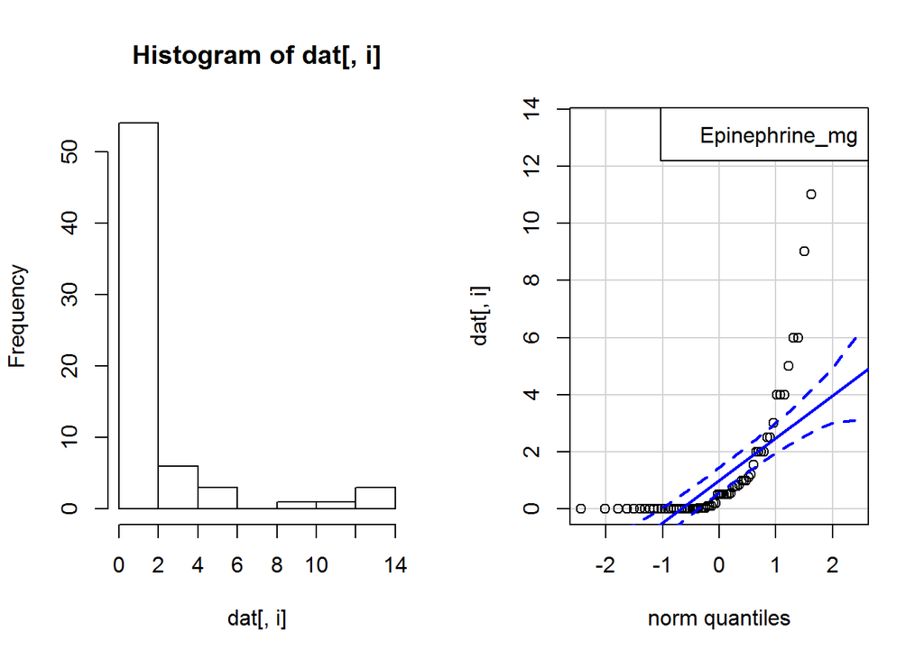

```
## [1] "Epinephrine_mg"
##
##  Shapiro-Wilk normality test
##
## data:  dat[, i]
## W = 0.58914, p-value = 1.675e-12
```

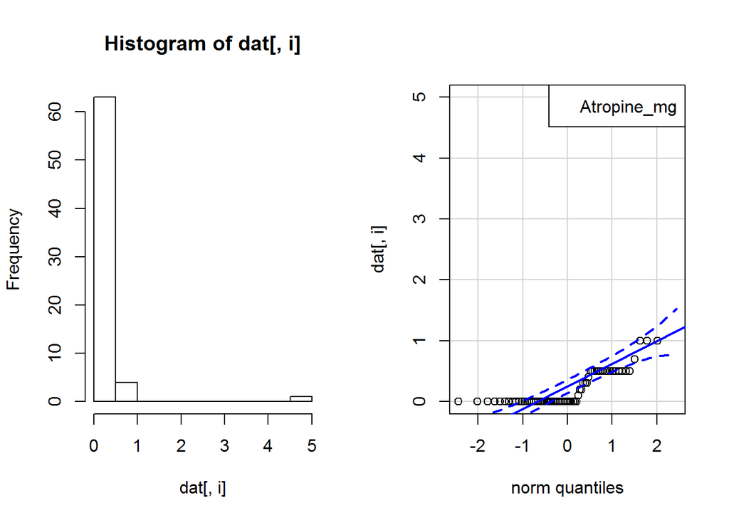

```
## [1] "Atropine_mg"
##
##  Shapiro-Wilk normality test
##
## data:  dat[, i]
## W = 0.39284, p-value = 2.857e-15
```

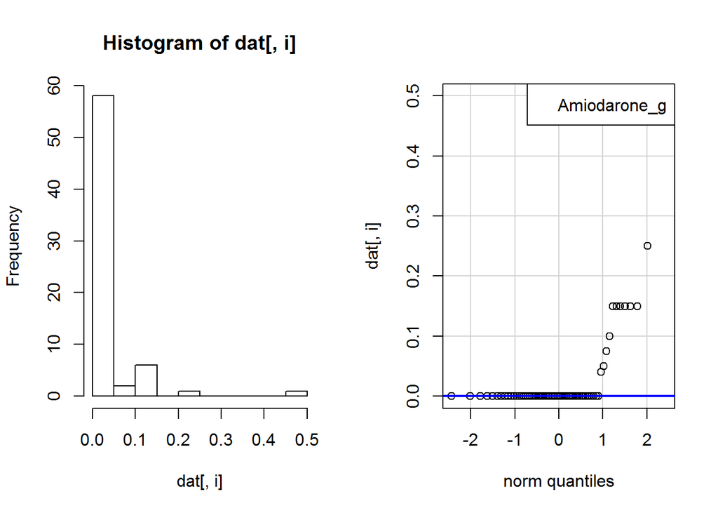

```
## [1] "Amiodarone_g"
##
##  Shapiro-Wilk normality test
##
## data:  dat[, i]
## W = 0.41307, p-value = 5.109e-15
```

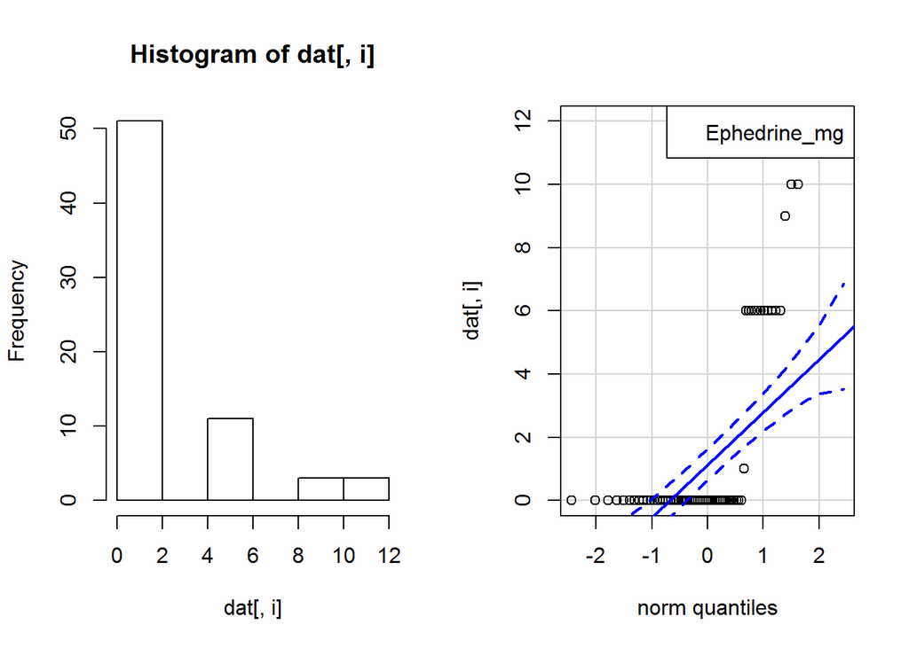

```
## [1] "Ephedrine_mg"
##
##  Shapiro-Wilk normality test
##
## data:  dat[, i]
## W = 0.59119, p-value = 1.809e-12
```

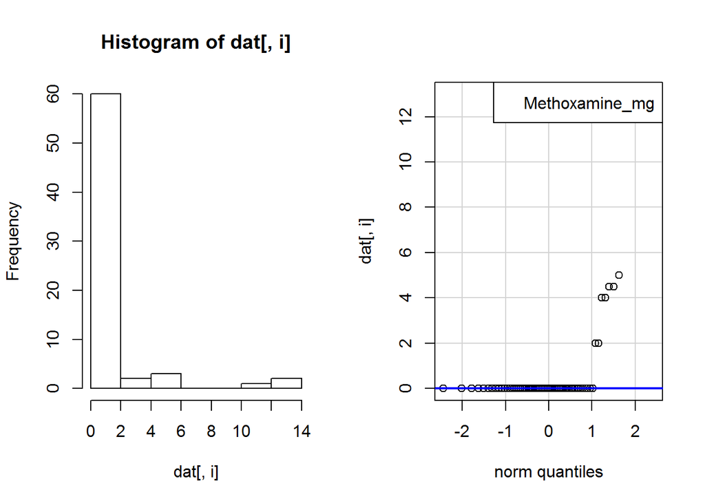

```
## [1] "Methoxamine_mg"
##
##  Shapiro-Wilk normality test
##
## data:  dat[, i]
## W = 0.38111, p-value = 2.053e-15
```

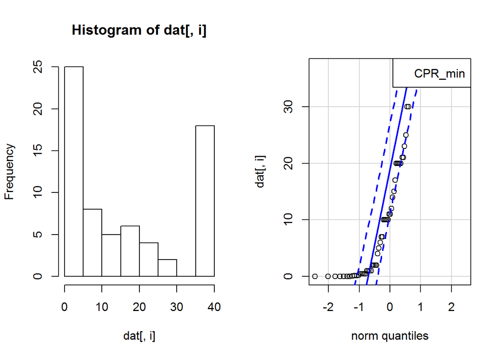

```
## [1] "CPR_min"
##
##  Shapiro-Wilk normality test
##
## data:  dat[, i]
## W = 0.82303, p-value = 1.421e-07
```

```r
# empty legend text
#legend_text <- c(data)

for (i in my_seq) { # variables to compare
  dat <- data %>%
    filter(Outcome=='Survived')
    par(mfrow = c(1, 2)) # combine plots
    hist(dat[, i])
    qqPlot(dat[, i],id = FALSE # id = FALSE to remove point identification
       ) # add next legend text
    legend_text <- colnames(dat)[i]  # plot legend once
      legend('topright', legend = legend_text)
      print(colnames(dat)[i])
      print(shapiro.test(dat[, i])) # print results of Shapiro-Wilk test
}
```

```r
#H0: the data follow a normal distribution; H1: the data do not follow a normal distribution
#the p-value>0.05 implys that we do not reject the null hypothesis
#In practice, normality tests are often considered as too conservative in the sense that for large sample size (
#n> 50), a small deviation from the normality may cause the normality condition to be violated


print('in regard to outcome status=Died')
```

```
## [1] "in regard to outcome status=Died"
```

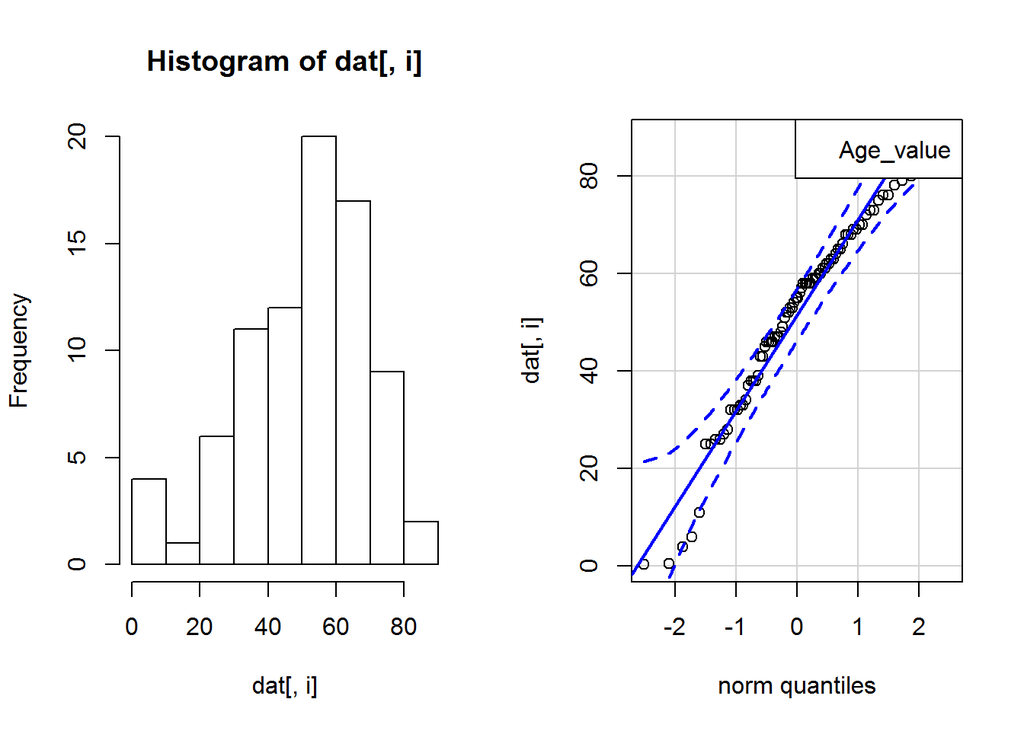

```
## [1] "Age_value"
##
##  Shapiro-Wilk normality test
##
## data:  dat[, i]
## W = 0.95984, p-value = 0.01162
```

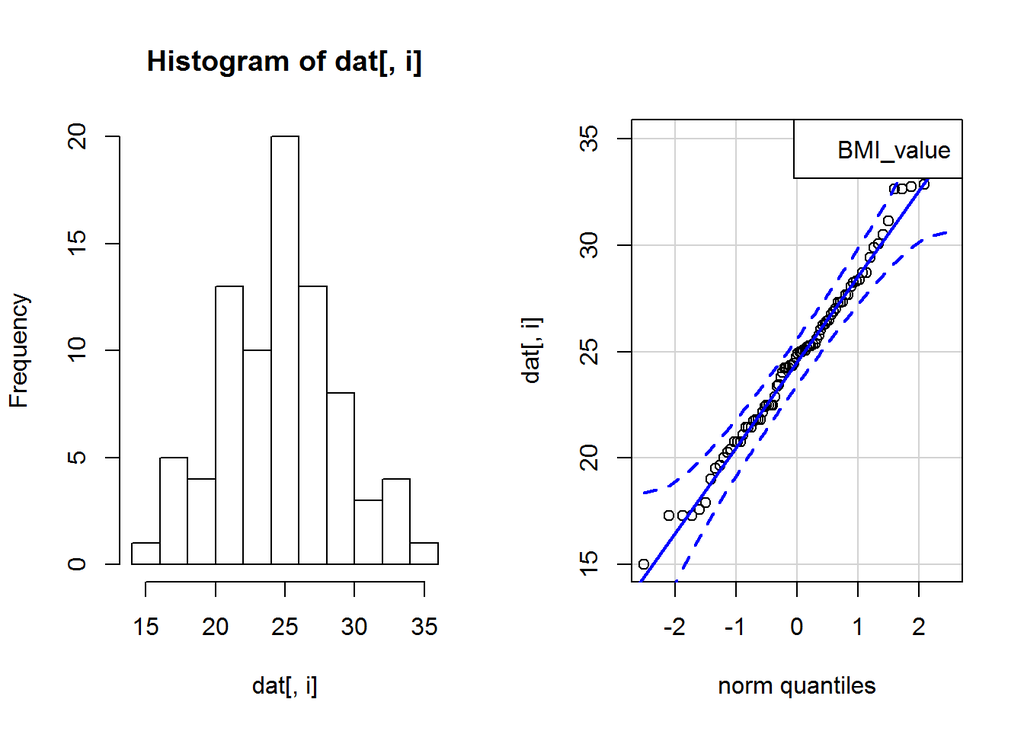

```
## [1] "BMI_value"
##
##  Shapiro-Wilk normality test
##
## data:  dat[, i]
## W = 0.99118, p-value = 0.8544
```

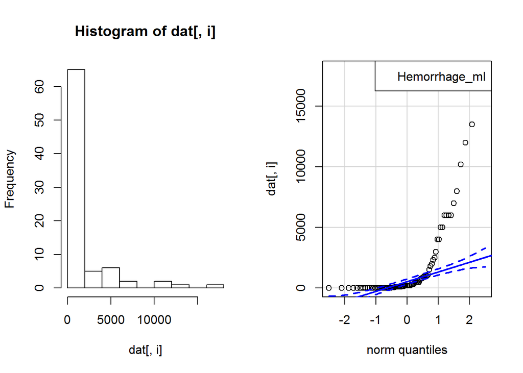

```
## [1] "Hemorrhage_ml"
##
##  Shapiro-Wilk normality test
##
## data:  dat[, i]
## W = 0.56845, p-value = 3.736e-14
```

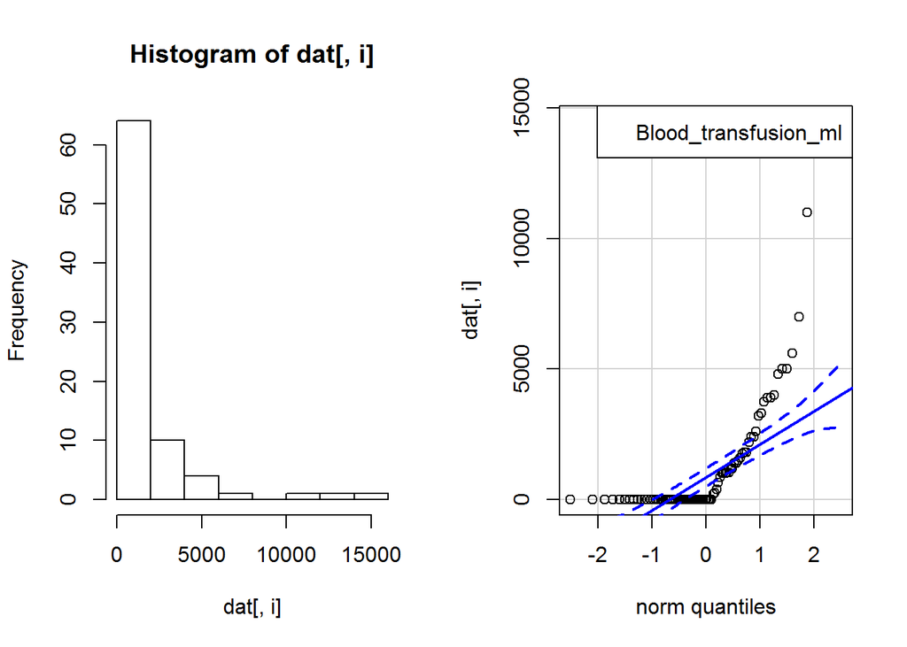

```
## [1] "Blood_transfusion_ml"
##
##  Shapiro-Wilk normality test
##
## data:  dat[, i]
## W = 0.57879, p-value = 5.592e-14
```

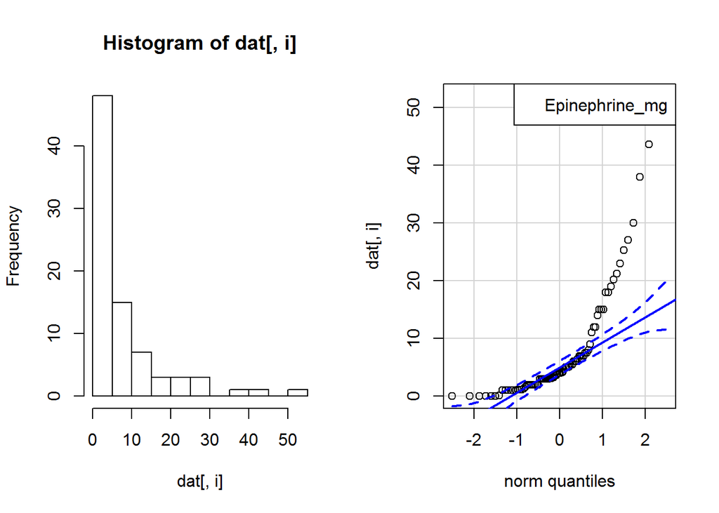

```
## [1] "Epinephrine_mg"
##
##  Shapiro-Wilk normality test
##
## data:  dat[, i]
## W = 0.70795, p-value = 1.764e-11
```

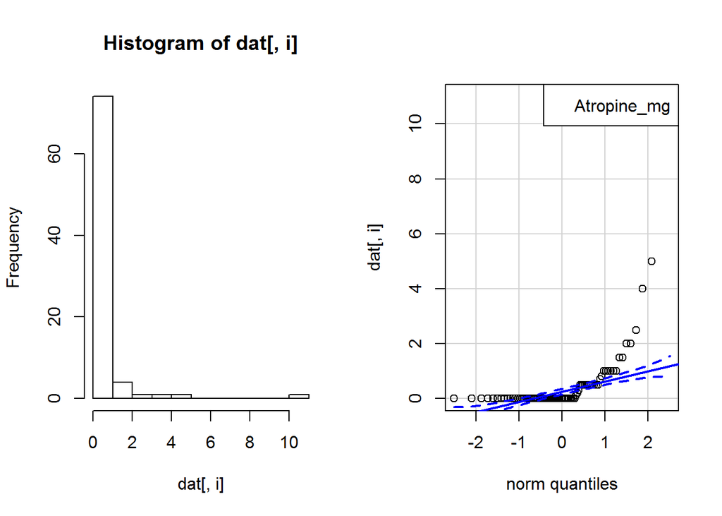

```
## [1] "Atropine_mg"
##
##  Shapiro-Wilk normality test
##
## data:  dat[, i]
## W = 0.39454, p-value < 2.2e-16
```

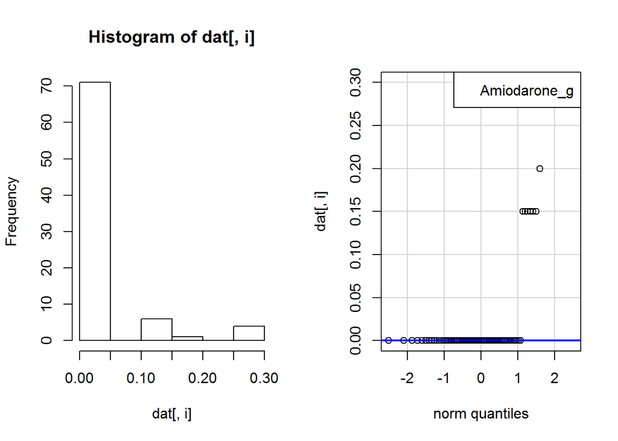

```
## [1] "Amiodarone_g"
##
##  Shapiro-Wilk normality test
##
## data:  dat[, i]
## W = 0.41214, p-value < 2.2e-16
```

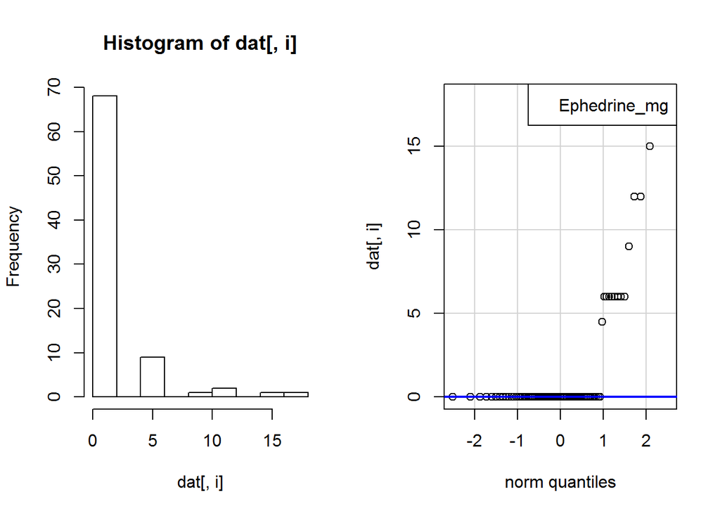

```
## [1] "Ephedrine_mg"
##
##  Shapiro-Wilk normality test
##
## data:  dat[, i]
## W = 0.46391, p-value = 8.938e-16
```

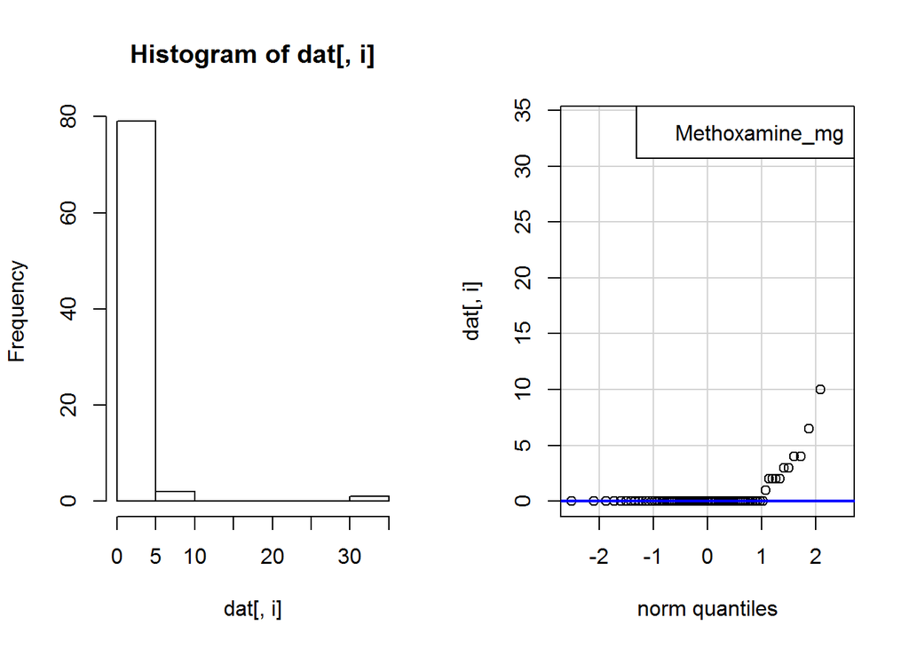

```
## [1] "Methoxamine_mg"
##
##  Shapiro-Wilk normality test
##
## data:  dat[, i]
## W = 0.22913, p-value < 2.2e-16
```

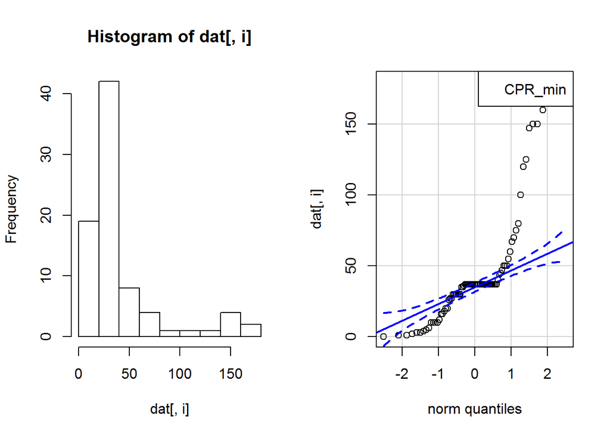

```
## [1] "CPR_min"
##
##  Shapiro-Wilk normality test
##
## data:  dat[, i]
## W = 0.73704, p-value = 8.166e-11
```

```r
# empty legend text
#legend_text <- c(data)

for (i in my_seq) { # variables to compare
  dat <- data %>%
    filter(Outcome=='Died')
    par(mfrow = c(1, 2)) # combine plots
    hist(dat[, i])
    qqPlot(dat[, i],id = FALSE # id = FALSE to remove point identification
       ) # add next legend text
    legend_text <- colnames(dat)[i]  # plot legend once
      legend('topright', legend = legend_text)
      print(colnames(dat)[i])
      print(shapiro.test(dat[, i])) # print results of Shapiro-Wilk test
}
```